# Case Study - 1 - DeAlmeida

Davis Vaughan

9/6/2017

## Building a Life Table in R

```r
library(tidyverse)
```

### Add ages

“Current industry mortality tables stop at age 121.”

```r
# A vector 65, 66, ..., 121
ages_vector <- 65:121
# Create a "tibble". Basically a data frame.
# Columns are specified as `col_name = col_data`
life_table <- tibble(ages = ages_vector)
life_table
```

| ages |
| --- |
| 65 |
| 66 |
| 67 |
| 68 |
| 69 |
| 70 |
| 71 |
| 72 |
| 73 |
| 74 |

[output cut: 47 more lines]

### Add the current year

We will also want to have a variable for the current year, `t`, starting at 0.

```r
life_table <- life_table %>%
  mutate(t = ages - 65)
life_table
```

| ages | t |
| --- | --- |
| 65 | 0 |
| 66 | 1 |
| 67 | 2 |
| 68 | 3 |
| 69 | 4 |
| 70 | 5 |
| 71 | 6 |
| 72 | 7 |
| 73 | 8 |
| 74 | 9 |

[output cut: 47 more lines]

### Add your p’s and q’s

“Assume 10 lives per 1000 mortality at age 65.”

$$q_{65} = 0.01$$

$$p_{65} = 0.99$$

“The *force of mortality* increases by 10% every year.”

What does this mean? It means we could write the sequence of increasing force of mortality values as:

$$\begin{align}
\mu_{x} &= \mu \\
\mu_{x+1} &= \mu * 1.1 \\
\mu_{x+2} &= \mu * 1.1^2
\end{align}$$

So $\mu$ is a constant…

And how do we relate force of mortality to probability of survival?

$$p_x = e ^ {-\int_{0}^{1} \mu_x dx}$$

For $p_{65}$, let $\mu_{65} = \mu$.

$$\begin{align}
p_{65} &= e ^ {-\int_{0}^{1} \mu dx} \\ &= e^{(-\mu*1) -(-\mu * 0)} \\ &= e ^ {-\mu}
\end{align}$$

From $p_{65}$ to $p_{66}$, what happens? Force of mortality increases by 10%.

$$\begin{align}
p_{66} &= e ^ {-1.1 \times\mu} \\ &= (e ^ {-\mu} ) ^ {1.1} \\ &= (p_{65}) ^ {1.1}
\end{align}$$

From $p_{66}$ to $p_{67}$, what happens? Force of mortality increases by 10%.

$$\begin{align}
p_{67} &= e ^ {-1.1^2 \times\mu} \\ &= (e ^ {-\mu} ) ^ {1.1^2} \\ &= (p_{65}) ^ {1.1^2}
\end{align}$$

The pattern emerges…

$$p_{65} = (p_{65}) ^ {1.1^0} \\ p_{66} = (p_{65}) ^ {1.1^1} \\ p_{67} = (p_{65}) ^ {1.1^2} \\ ... \\ p_{65 + t} = (0.99) ^ {1.1^t}$$

$$q_{65 + t} = 1 - p_{65 + t}$$

```r
life_table <- life_table %>%
  mutate(
    `p_65+t` = .99 ^ (1.1 ^ t),
    `q_65+t` = 1 - `p_65+t`
  )
life_table
```

| ages | t | p_65+t | q_65+t |
| --- | --- | --- | --- |
| 65 | 0 | 0.9900000 | 0.01000000 |
| 66 | 1 | 0.9890055 | 0.01099448 |
| 67 | 2 | 0.9879127 | 0.01208726 |
| 68 | 3 | 0.9867121 | 0.01328792 |
| 69 | 4 | 0.9853930 | 0.01460696 |
| 70 | 5 | 0.9839441 | 0.01605587 |
| 71 | 6 | 0.9823528 | 0.01764721 |
| 72 | 7 | 0.9806053 | 0.01939472 |
| 73 | 8 | 0.9786866 | 0.02131338 |
| 74 | 9 | 0.9765804 | 0.02341957 |

[output cut: 47 more lines]

### A visualization

It’s worth checking out what we have done so far. Let’s look at increasing mortality over time.

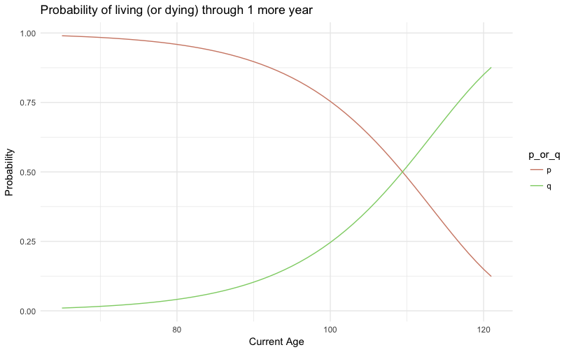

```r
life_table %>%

  # Renaming columns. These become the legend labels
  rename(p = `p_65+t`, q = `q_65+t`) %>%

  # Gather p and q columns together
  gather(key = p_or_q, value = prob, -ages, -t) %>%

  # The code that creates the plot
  ggplot(aes(x = ages, y = prob, color = p_or_q)) +
  geom_line() +

  # Customization
  labs(x = "Current Age", y = "Probability",
       title = "Probability of living (or dying) through 1 more year") +
  theme_minimal() +
  hrbrthemes::scale_color_ipsum()
```

### Adding $_{t}p_{65}$

We have $p_{65+t}$, how do we generate $_{t}p_{65}$ from this?

At first glance, this might seem difficult. In Excel we went back and forth between columns E and F a lot, and had the special case of $_{0}p_{65} = 1$ at the beginning.

It’s totally possible to do this in R, but you would have to use a *for loop* to implement that recursive calculation. Can we do something smarter?

Let’s explore a few iterations of $_{t}p_{65}$.

$$\begin{align}
_{0}p_{65} &= 1 \\
_{1}p_{65} &= p_{65 + 0} \\
_{2}p_{65} &= p_{65 + 0} \times p_{65 + 1} &= _{1}p_{65} \times p_{65 + 1} \\
_{3}p_{65} &= p_{65 + 0} \times p_{65 + 1} \times p_{65 + 2} &= _{2}p_{65} \times p_{65 + 2}
\end{align}$$

Notice that the middle equations there are a *cumulative product* of $p_{65+t}$.

$$\begin{align}
\text{original} &\rightarrow \text{cumprod} &= _{t}p_{65} \\
1 &\rightarrow 1 &= _{0}p_{65} \\
p_{65 + 0} &\rightarrow 1 \times p_{65 + 0} &= _{1}p_{65} \\
p_{65 + 1} &\rightarrow 1 \times p_{65 + 0} \times p_{65 + 1} &= _{2}p_{65} \\
p_{65 + 2} &\rightarrow 1 \times p_{65 + 0} \times p_{65 + 1} \times p_{65 + 2} &= _{3}p_{65} \\
\end{align}$$

Steps to accomplish this in R?

1. Lag (shift down) $p_{65+t}$
2. Fill in a 1 where we lost a value from the lag
3. Cumulative product of that column to generate $_{t}p_{65}$

```r
# An initial attempt at lagging p_{65+t}
life_table %>%
  mutate(
    p_lag = lag(`p_65+t`)
  )
```

| ages | t | p_65+t | q_65+t | p_lag |
| --- | --- | --- | --- | --- |
| 65 | 0 | 0.9900000 | 0.01000000 | NA |
| 66 | 1 | 0.9890055 | 0.01099448 | 0.9900000 |
| 67 | 2 | 0.9879127 | 0.01208726 | 0.9890055 |
| 68 | 3 | 0.9867121 | 0.01328792 | 0.9879127 |
| 69 | 4 | 0.9853930 | 0.01460696 | 0.9867121 |
| 70 | 5 | 0.9839441 | 0.01605587 | 0.9853930 |
| 71 | 6 | 0.9823528 | 0.01764721 | 0.9839441 |
| 72 | 7 | 0.9806053 | 0.01939472 | 0.9823528 |
| 73 | 8 | 0.9786866 | 0.02131338 | 0.9806053 |
| 74 | 9 | 0.9765804 | 0.02341957 | 0.9786866 |

[output cut: 47 more lines]

```r
# Lagging p_{65+t} but filling the NA with 1
life_table %>%
  mutate(
    p_lag               = lag(`p_65+t`),
    p_lag_1             = lag(`p_65+t`, default = 1)
  )
```

| ages | t | p_65+t | q_65+t | p_lag | p_lag_1 |
| --- | --- | --- | --- | --- | --- |
| 65 | 0 | 0.9900000 | 0.01000000 | NA | 1.0000000 |
| 66 | 1 | 0.9890055 | 0.01099448 | 0.9900000 | 0.9900000 |
| 67 | 2 | 0.9879127 | 0.01208726 | 0.9890055 | 0.9890055 |
| 68 | 3 | 0.9867121 | 0.01328792 | 0.9879127 | 0.9879127 |
| 69 | 4 | 0.9853930 | 0.01460696 | 0.9867121 | 0.9867121 |
| 70 | 5 | 0.9839441 | 0.01605587 | 0.9853930 | 0.9853930 |
| 71 | 6 | 0.9823528 | 0.01764721 | 0.9839441 | 0.9839441 |
| 72 | 7 | 0.9806053 | 0.01939472 | 0.9823528 | 0.9823528 |
| 73 | 8 | 0.9786866 | 0.02131338 | 0.9806053 | 0.9806053 |
| 74 | 9 | 0.9765804 | 0.02341957 | 0.9786866 | 0.9786866 |

[output cut: 47 more lines]

```r
# Now take the cumulative product of those lagged values
life_table %>%
  mutate(
    p_lag               = lag(`p_65+t`),
    p_lag_1             = lag(`p_65+t`, default = 1),
    p_lag_cumprod       = lag(`p_65+t`, default = 1) %>% cumprod()
  )
```

| ages | t | p_65+t | q_65+t | p_lag | p_lag_1 | p_lag_cumprod |
| --- | --- | --- | --- | --- | --- | --- |
| 65 | 0 | 0.9900000 | 0.01000000 | NA | 1.0000000 | 1.000000e+00 |
| 66 | 1 | 0.9890055 | 0.01099448 | 0.9900000 | 0.9900000 | 9.900000e-01 |
| 67 | 2 | 0.9879127 | 0.01208726 | 0.9890055 | 0.9890055 | 9.791155e-01 |
| 68 | 3 | 0.9867121 | 0.01328792 | 0.9879127 | 0.9879127 | 9.672806e-01 |
| 69 | 4 | 0.9853930 | 0.01460696 | 0.9867121 | 0.9867121 | 9.544275e-01 |
| 70 | 5 | 0.9839441 | 0.01605587 | 0.9853930 | 0.9853930 | 9.404862e-01 |
| 71 | 6 | 0.9823528 | 0.01764721 | 0.9839441 | 0.9839441 | 9.253859e-01 |
| 72 | 7 | 0.9806053 | 0.01939472 | 0.9823528 | 0.9823528 | 9.090554e-01 |
| 73 | 8 | 0.9786866 | 0.02131338 | 0.9806053 | 0.9806053 | 8.914245e-01 |
| 74 | 9 | 0.9765804 | 0.02341957 | 0.9786866 | 0.9786866 | 8.724252e-01 |

[output cut: 47 more lines]

```r
# That was kind of ugly, let's round a bit
life_table %>%
  mutate(
    p_lag               = lag(`p_65+t`),
    p_lag_1             = lag(`p_65+t`, default = 1),
    p_lag_cumprod       = lag(`p_65+t`, default = 1) %>% cumprod(),
    p_lag_cumprod_round = lag(`p_65+t`, default = 1) %>% cumprod() %>% round(digits = 6)
  )
```

| ages | t | p_65+t | q_65+t | p_lag | p_lag_1 | p_lag_cumprod | p_lag_cumprod_round |
| --- | --- | --- | --- | --- | --- | --- | --- |
| 65 | 0 | 0.9900000 | 0.01000000 | NA | 1.0000000 | 1.000000e+00 | 1.000000 |
| 66 | 1 | 0.9890055 | 0.01099448 | 0.9900000 | 0.9900000 | 9.900000e-01 | 0.990000 |
| 67 | 2 | 0.9879127 | 0.01208726 | 0.9890055 | 0.9890055 | 9.791155e-01 | 0.979115 |
| 68 | 3 | 0.9867121 | 0.01328792 | 0.9879127 | 0.9879127 | 9.672806e-01 | 0.967281 |
| 69 | 4 | 0.9853930 | 0.01460696 | 0.9867121 | 0.9867121 | 9.544275e-01 | 0.954427 |
| 70 | 5 | 0.9839441 | 0.01605587 | 0.9853930 | 0.9853930 | 9.404862e-01 | 0.940486 |
| 71 | 6 | 0.9823528 | 0.01764721 | 0.9839441 | 0.9839441 | 9.253859e-01 | 0.925386 |
| 72 | 7 | 0.9806053 | 0.01939472 | 0.9823528 | 0.9823528 | 9.090554e-01 | 0.909055 |
| 73 | 8 | 0.9786866 | 0.02131338 | 0.9806053 | 0.9806053 | 8.914245e-01 | 0.891425 |
| 74 | 9 | 0.9765804 | 0.02341957 | 0.9786866 | 0.9786866 | 8.724252e-01 | 0.872425 |

[output cut: 47 more lines]

```r
# Now let's just do it all in one step and save it as `t_p_65`
life_table <- life_table %>%
  mutate(
    `t_p_65` = lag(`p_65+t`, default = 1) %>%
                  cumprod() %>%
                  round(digits = 6)
  )
life_table
```

| ages | t | p_65+t | q_65+t | t_p_65 |
| --- | --- | --- | --- | --- |
| 65 | 0 | 0.9900000 | 0.01000000 | 1.000000 |
| 66 | 1 | 0.9890055 | 0.01099448 | 0.990000 |
| 67 | 2 | 0.9879127 | 0.01208726 | 0.979115 |
| 68 | 3 | 0.9867121 | 0.01328792 | 0.967281 |
| 69 | 4 | 0.9853930 | 0.01460696 | 0.954427 |
| 70 | 5 | 0.9839441 | 0.01605587 | 0.940486 |
| 71 | 6 | 0.9823528 | 0.01764721 | 0.925386 |
| 72 | 7 | 0.9806053 | 0.01939472 | 0.909055 |
| 73 | 8 | 0.9786866 | 0.02131338 | 0.891425 |
| 74 | 9 | 0.9765804 | 0.02341957 | 0.872425 |

[output cut: 47 more lines]

### Another visualization!

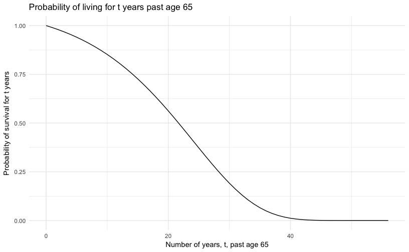

```r
life_table %>%

  # The code that creates the plot
  ggplot(aes(x = t, y = t_p_65)) +
  geom_line() +

  # Customization
  labs(x = "Number of years, t, past age 65", y = "Probability of survival for t years",
       title = "Probability of living for t years past age 65") +
  theme_minimal() +
  hrbrthemes::scale_color_ipsum()
```

### Finally, $l_{65 + t}$

Use the formula:

$$_{t}p_{65} = \frac{l_{65+t}}{l_{65}}$$

Rearrange:

$$l_{65+t} = l_{65} \times _{t}p_{65}$$

- We know $l_{65} = 600$
- We calculated the column $_{t}p_{65}$

```r
# Original number of lives
l_65 = 600
# Calculate number of people alive at time t
life_table <- life_table %>%
  mutate(
    `l_65+t` = l_65 * t_p_65
  )
# Just round everything to 4 decimal places for pretty printing
life_table %>%
  modify(~round(.x, 4))
```

| ages | t | p_65+t | q_65+t | t_p_65 | l_65+t |
| --- | --- | --- | --- | --- | --- |
| 65 | 0 | 0.9900 | 0.0100 | 1.0000 | 600.0000 |
| 66 | 1 | 0.9890 | 0.0110 | 0.9900 | 594.0000 |
| 67 | 2 | 0.9879 | 0.0121 | 0.9791 | 587.4690 |
| 68 | 3 | 0.9867 | 0.0133 | 0.9673 | 580.3686 |
| 69 | 4 | 0.9854 | 0.0146 | 0.9544 | 572.6562 |
| 70 | 5 | 0.9839 | 0.0161 | 0.9405 | 564.2916 |
| 71 | 6 | 0.9824 | 0.0176 | 0.9254 | 555.2316 |
| 72 | 7 | 0.9806 | 0.0194 | 0.9091 | 545.4330 |
| 73 | 8 | 0.9787 | 0.0213 | 0.8914 | 534.8550 |
| 74 | 9 | 0.9766 | 0.0234 | 0.8724 | 523.4550 |

[output cut: 47 more lines]

### One last visualization

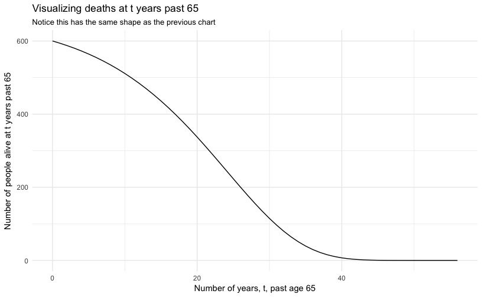

```r
life_table %>%

  # The code that creates the plot
  ggplot(aes(x = t, y = `l_65+t`)) +
  geom_line() +

  # Customization
  labs(x        = "Number of years, t, past age 65",
       y        = "Number of people alive at t years past 65",
       title    = "Visualizing deaths at t years past 65",
       subtitle = "Notice this has the same shape as the previous chart") +
  theme_minimal() +
  hrbrthemes::scale_color_ipsum()
```

### Without the explanation, how much code?

```r
# Parameters
initial_age  <- 65
ending_age   <- 121
l_x          <- 600      # 60mil / 100thousand
initial_q    <- 10/1000  # 10 lives out of 1000 at 65
f_o_m_factor <- 1.1      # from the 10% increase each year
# Age range
age_range <- initial_age:ending_age
# Initialize table with ages
life_table <- tibble(ages = age_range)
# Add all the other columns
life_table <- life_table %>%
  mutate(

    # Add the t years
    t = ages - initial_age,

    # p using the force of mortality factor
    `p_x+t` = (1 - initial_q) ^ (f_o_m_factor ^ t),

    # q is 1-p
    `q_x+t` = 1 - `p_x+t`,

    # t_p_x from p
    `t_p_x` = lag(`p_x+t`, default = 1) %>% cumprod(),

    # Number of lives left
    `l_x+t` = l_x * t_p_x
  )
life_table %>%
  modify(~round(.x, 4))
```

| ages | t | p_x+t | q_x+t | t_p_x | l_x+t |
| --- | --- | --- | --- | --- | --- |
| 65 | 0 | 0.9900 | 0.0100 | 1.0000 | 600.0000 |
| 66 | 1 | 0.9890 | 0.0110 | 0.9900 | 594.0000 |
| 67 | 2 | 0.9879 | 0.0121 | 0.9791 | 587.4693 |
| 68 | 3 | 0.9867 | 0.0133 | 0.9673 | 580.3684 |
| 69 | 4 | 0.9854 | 0.0146 | 0.9544 | 572.6565 |
| 70 | 5 | 0.9839 | 0.0161 | 0.9405 | 564.2917 |
| 71 | 6 | 0.9824 | 0.0176 | 0.9254 | 555.2315 |
| 72 | 7 | 0.9806 | 0.0194 | 0.9091 | 545.4332 |
| 73 | 8 | 0.9787 | 0.0213 | 0.8914 | 534.8547 |
| 74 | 9 | 0.9766 | 0.0234 | 0.8724 | 523.4551 |

[output cut: 47 more lines]